# Maize-Teosinte limma DE

Caryn Johansen

9/25/2017

# Introduction

I used RNA-seq data from Lemmon et al. 2014 (http://journals.plos.org/plosgenetics/article?id=10.1371/journal.pgen.1004745), downloaded from the SRA (https://www.ncbi.nlm.nih.gov/bioproject/PRJNA262181)

```
fastq-dump --outdir data/raw --gzip --skip-technical --readids --read-filter pass --dumpbase --clip -fasta $srr
```

Index was created from the AGPv4 full genome cdna (ftp://ftp.ensemblgenomes.org/pub/plants/release-37/fasta/zea_mays/cdna/)

```
kallisto index -i $idx $cdna
```

**all details for scripts found in the project folder:** `Projects/Highland_GeneticIncompatibility/TeoMaizeCrossTest/scripts`

Kallisto code found `scripts` under `kallisto.sh`. The general command was:

```
kallisto quant -i $idx -o data/bootstrap100/$srr -b 100 --single -l 101 -s 20 data/raw/$fastq
```

For the analysis for differential expression, I am using limma

package found at: http://bioconductor.org/packages/release/bioc/html/limma.html

# Setup

```r
library(limma)
library(tidyverse)
library(reshape2)
```

# Data

SRA samples:

```r
sample_id <- dir(file.path("data/fullTranscript/"))
sample_id
```

```
##  [1] "SRR1586618" "SRR1586619" "SRR1586620" "SRR1586621" "SRR1586736"
##  [6] "SRR1586747" "SRR1586766" "SRR1586767" "SRR1586768" "SRR1586888"
## [11] "SRR1586889" "SRR1586898" "SRR1586899"
```

Get the file path for kallisto output

```r
kal_results <- file.path("data/fullTranscript", sample_id)
kal_results
```

```
##  [1] "data/fullTranscript/SRR1586618" "data/fullTranscript/SRR1586619"
##  [3] "data/fullTranscript/SRR1586620" "data/fullTranscript/SRR1586621"
##  [5] "data/fullTranscript/SRR1586736" "data/fullTranscript/SRR1586747"
##  [7] "data/fullTranscript/SRR1586766" "data/fullTranscript/SRR1586767"
##  [9] "data/fullTranscript/SRR1586768" "data/fullTranscript/SRR1586888"
## [11] "data/fullTranscript/SRR1586889" "data/fullTranscript/SRR1586898"
## [13] "data/fullTranscript/SRR1586899"
```

```r
res <- as.data.frame(cbind(sample_id, kal_results))
res
```

```
##     sample_id                    kal_results
## 1  SRR1586618 data/fullTranscript/SRR1586618
## 2  SRR1586619 data/fullTranscript/SRR1586619
## 3  SRR1586620 data/fullTranscript/SRR1586620
## 4  SRR1586621 data/fullTranscript/SRR1586621
## 5  SRR1586736 data/fullTranscript/SRR1586736
## 6  SRR1586747 data/fullTranscript/SRR1586747
## 7  SRR1586766 data/fullTranscript/SRR1586766
## 8  SRR1586767 data/fullTranscript/SRR1586767
## 9  SRR1586768 data/fullTranscript/SRR1586768
## 10 SRR1586888 data/fullTranscript/SRR1586888
## 11 SRR1586889 data/fullTranscript/SRR1586889
## 12 SRR1586898 data/fullTranscript/SRR1586898
## 13 SRR1586899 data/fullTranscript/SRR1586899
```

Generate the data structure to provide sleuth with the design matrix.

There are two tissue types here, but I really only want to do leaf until I have a reason to do both tissues.

```r
meta <- read.table("simple_meta.txt", header=T, sep = " ", stringsAsFactors = T)
meta_leaf <- dplyr::filter(meta, tissue_s == "leaf")
meta_leaf <- dplyr::select(meta_leaf, sample=Run_s, cultivar=cultivar_s)
str(meta_leaf)
```

```
## 'data.frame':    7 obs. of  2 variables:
##  $ sample  : Factor w/ 14 levels "SRR1586618","SRR1586619",..: 8 9 10 11 12 13 14
##  $ cultivar: Factor w/ 3 levels "B73","B73_TIL01",..: 2 2 2 1 1 3 3
```

```r
sample_leaf <- as.character(meta_leaf$sample)
res_leaf <- res[as.character(res$sample_id) %in% sample_leaf,]
meta_leaf <- dplyr::mutate(meta_leaf, path=as.character(res_leaf$kal_results))
meta_leaf
```

```
##       sample  cultivar                           path
## 1 SRR1586766 B73_TIL01 data/fullTranscript/SRR1586766
## 2 SRR1586767 B73_TIL01 data/fullTranscript/SRR1586767
## 3 SRR1586768 B73_TIL01 data/fullTranscript/SRR1586768
## 4 SRR1586888       B73 data/fullTranscript/SRR1586888
## 5 SRR1586889       B73 data/fullTranscript/SRR1586889
## 6 SRR1586898     TIL01 data/fullTranscript/SRR1586898
## 7 SRR1586899     TIL01 data/fullTranscript/SRR1586899
```

Create data matrix with tpm

```r
file <- "abundance.tsv"

full_file <- paste(res_leaf$kal_results, file, sep="/")

ab_list <- list()

for(i in 1:length(full_file)) {
  sample <- as.character(res_leaf$sample_id[i])

  ab <- read.table(full_file[i], header=T, sep="\t")
  #do.call("<-", list(res_leaf$sample_id[i], ab)) # assign each abundance file to its SRR

  #create the gene column
  transcripts <- as.character(ab$target_id)
  transcript_split <- strsplit(transcripts, "_")
  transcripts <- as.data.frame(do.call(rbind,transcript_split))
  colnames(transcripts) <- c("gene", "transcript_id")
  ab$gene <- transcripts$gene

  # get the gene counts
  g <- ab %>%
    group_by(gene) %>%
    summarise(est_counts_sum=sum(tpm))
  #do.call("<-", list(genedf, g))
  g <- data.frame(g)
  rownames(g) <- g$gene
  g$gene <- NULL
  colnames(g) <- sample
  ab_list[[sample]] <- g
}

gene_tpm <- do.call(cbind, ab_list)
```

Create data matrix with estimated counts:

```r
ab_list <- list()

for(i in 1:length(full_file)) {
  sample <- as.character(res_leaf$sample_id[i])

  ab <- read.table(full_file[i], header=T, sep="\t")
  #do.call("<-", list(res_leaf$sample_id[i], ab)) # assign each abundance file to its SRR

  #create the gene column
  transcripts <- as.character(ab$target_id)
  transcript_split <- strsplit(transcripts, "_")
  transcripts <- as.data.frame(do.call(rbind,transcript_split))
  colnames(transcripts) <- c("gene", "transcript_id")
  ab$gene <- transcripts$gene

  # get the gene counts
  g <- ab %>%
    group_by(gene) %>%
    summarise(est_counts_sum=sum(est_counts))
  #do.call("<-", list(genedf, g))
  g <- data.frame(g)
  rownames(g) <- g$gene
  g$gene <- NULL
  colnames(g) <- sample
  ab_list[[sample]] <- g
}

gene_counts <- do.call(cbind, ab_list)
```

Long data frames:

```r
gene_count_long <- gene_counts
gene_count_long$gene <- rownames(gene_counts)
gene_count_long <- reshape2::melt(gene_count_long)
colnames(gene_count_long) <- c("gene", "sample", "est_count")

meta_leaf2 <- meta_leaf %>% select(-path)
gene_count_long <- gene_count_long %>% left_join(meta_leaf2, by = "sample")
gene_tpm_long <- gene_tpm
gene_tpm_long$gene <- rownames(gene_tpm)
gene_tpm_long <- reshape2::melt(gene_tpm_long)
colnames(gene_tpm_long) <- c("gene", "sample", "tpm")
gene_tpm_long <- gene_tpm_long %>% left_join(meta_leaf2, by = "sample")
```

Reorder sample for plotting

```r
gene_tpm_long$sample <- as.factor(gene_tpm_long$sample)
gene_tpm_long$sample <- factor(gene_tpm_long$sample,
                               levels = c("SRR1586888", "SRR1586889", "SRR1586766", "SRR1586767", "SRR1586768","SRR1586898","SRR1586899"))
```

# Analysis

## Design matrices

Full model

```r
meta_leaf$cultivar <- factor(meta_leaf$cultivar, levels=c("B73_TIL01", "B73", "TIL01"))
meta_leaf
```

```
##       sample  cultivar                           path
## 1 SRR1586766 B73_TIL01 data/fullTranscript/SRR1586766
## 2 SRR1586767 B73_TIL01 data/fullTranscript/SRR1586767
## 3 SRR1586768 B73_TIL01 data/fullTranscript/SRR1586768
## 4 SRR1586888       B73 data/fullTranscript/SRR1586888
## 5 SRR1586889       B73 data/fullTranscript/SRR1586889
## 6 SRR1586898     TIL01 data/fullTranscript/SRR1586898
## 7 SRR1586899     TIL01 data/fullTranscript/SRR1586899
```

```r
full_leaf_model <- model.matrix(~cultivar, meta_leaf)
full_leaf_model
```

```
##   (Intercept) cultivarB73 cultivarTIL01
## 1           1           0             0
## 2           1           0             0
## 3           1           0             0
## 4           1           1             0
## 5           1           1             0
## 6           1           0             1
## 7           1           0             1
## attr(,"assign")
## [1] 0 1 1
## attr(,"contrasts")
## attr(,"contrasts")$cultivar
## [1] "contr.treatment"
```

Make the reduced models:

```r
meta_leaf$B73 <- meta_leaf$cultivar == "B73"
meta_leaf$TIL01 <- meta_leaf$cultivar == "TIL01"
meta_leaf
```

```
##       sample  cultivar                           path   B73 TIL01
## 1 SRR1586766 B73_TIL01 data/fullTranscript/SRR1586766 FALSE FALSE
## 2 SRR1586767 B73_TIL01 data/fullTranscript/SRR1586767 FALSE FALSE
## 3 SRR1586768 B73_TIL01 data/fullTranscript/SRR1586768 FALSE FALSE
## 4 SRR1586888       B73 data/fullTranscript/SRR1586888  TRUE FALSE
## 5 SRR1586889       B73 data/fullTranscript/SRR1586889  TRUE FALSE
## 6 SRR1586898     TIL01 data/fullTranscript/SRR1586898 FALSE  TRUE
## 7 SRR1586899     TIL01 data/fullTranscript/SRR1586899 FALSE  TRUE
```

Null model for difference between cross and B73

```r
reduced_TIL01 <- model.matrix(~1 + TIL01, meta_leaf)
reduced_TIL01
```

```
##   (Intercept) TIL01TRUE
## 1           1         0
## 2           1         0
## 3           1         0
## 4           1         0
## 5           1         0
## 6           1         1
## 7           1         1
## attr(,"assign")
## [1] 0 1
## attr(,"contrasts")
## attr(,"contrasts")$TIL01
## [1] "contr.treatment"
```

Null model for difference between cross and TIL01

```r
reduced_B73 <- model.matrix(~1+B73, meta_leaf)
reduced_B73
```

```
##   (Intercept) B73TRUE
## 1           1       0
## 2           1       0
## 3           1       0
## 4           1       1
## 5           1       1
## 6           1       0
## 7           1       0
## attr(,"assign")
## [1] 0 1
## attr(,"contrasts")
## attr(,"contrasts")$B73
## [1] "contr.treatment"
```

## TPM

#### Create DGE object

```r
library(edgeR)
tpm_dge <- DGEList(counts = gene_tpm, group = as.factor(meta_leaf$sample))
tpm_dge <- calcNormFactors(tpm_dge)
```

**should I filter out for genes that are unexpressed across the board?**

#### voom/limma

Voom on full model

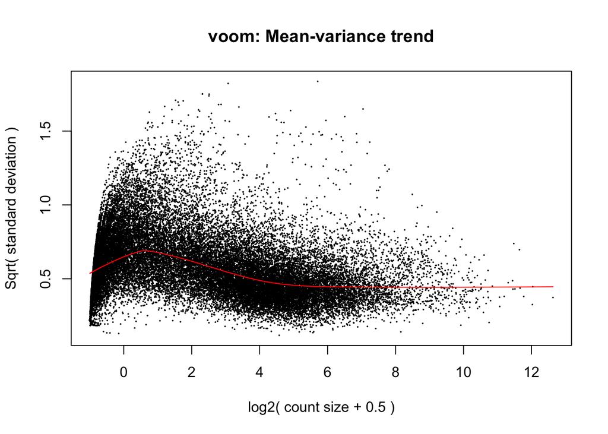

```r
tpm_v <- voom(tpm_dge, design = full_leaf_model, plot=TRUE)
```

Fit using limma

#### contrast for B73

Dropping the `cultivarB73` column of the design matrix. Results from this section will show F1 crosses that are differentially expressed from B73, but not necessarily from TIL01.

```r
fit <- lmFit(tpm_v, design = full_leaf_model)
fit <- eBayes(fit)
tpm_fit_B73 <- topTable(fit, n=nrow(tpm_v), confint = TRUE, coef = "cultivarB73")
tpm_fit_B73$gene <- rownames(tpm_fit_B73)
tpm_B73_top <- tpm_fit_B73 %>% filter(adj.P.Val <= 0.05) %>% arrange(P.Value)
dim(tpm_B73_top)
```

```
## [1] 3880    9
```

```r
head(tpm_B73_top)
```

```
##       logFC       CI.L      CI.R  AveExpr         t      P.Value
## 1 -5.329172  -5.575499 -5.082845 2.288294 -53.89523 8.268057e-09
## 2 -6.381705  -6.692692 -6.070717 3.860750 -51.12071 1.110378e-08
## 3 -9.872625 -10.444362 -9.300889 3.850114 -43.01696 2.907365e-08
## 4 -2.809502  -2.991779 -2.627225 5.187653 -38.39725 5.475980e-08
## 5 -4.464281  -4.755290 -4.173273 2.278985 -38.21629 5.622003e-08
## 6 -4.471640  -4.771617 -4.171663 2.665948 -37.13483 6.596830e-08
##      adj.P.Val        B           gene
## 1 0.0002192885 9.739141 Zm00001d049250
## 2 0.0002192885 8.475683 Zm00001d016947
## 3 0.0003284753 8.885039 Zm00001d024522
## 4 0.0003284753 9.049416 Zm00001d047808
## 5 0.0003284753 8.641233 Zm00001d024053
## 6 0.0003284753 8.549543 Zm00001d025265
```

Check out pvalues

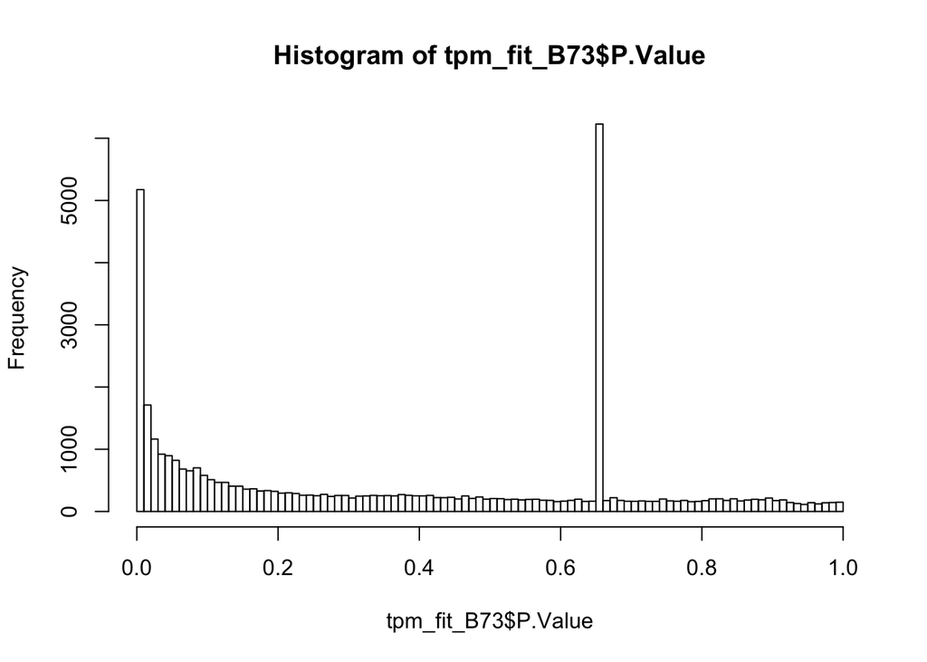

```r
hist(tpm_fit_B73$P.Value, breaks= 100)
```

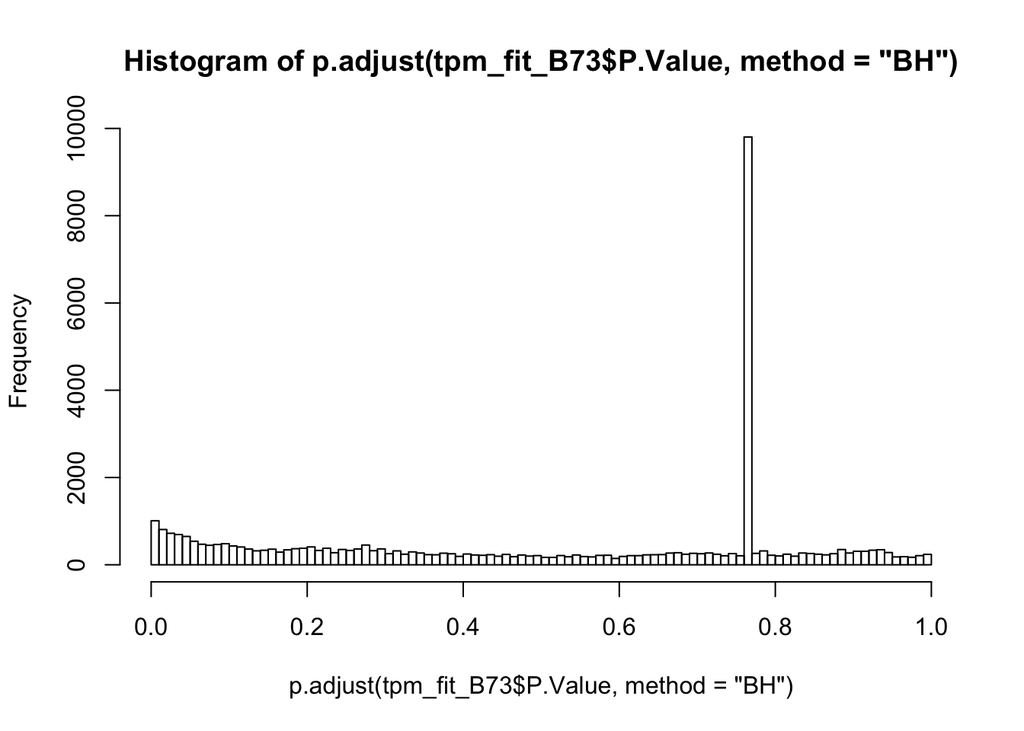

```r
hist(p.adjust(tpm_fit_B73$P.Value, method = "BH"), breaks=100)
```

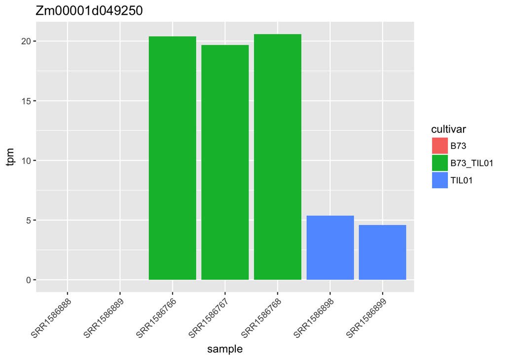

```r
gene_tpm_long %>% filter(gene == tpm_B73_top[1,]$gene) %>% ggplot() + geom_bar(aes(x=sample, y=tpm, fill=cultivar), stat = "identity") +
  theme(axis.text.x = element_text(angle = 45, hjust = 1)) + ggtitle(tpm_B73_top[1,]$gene)
```

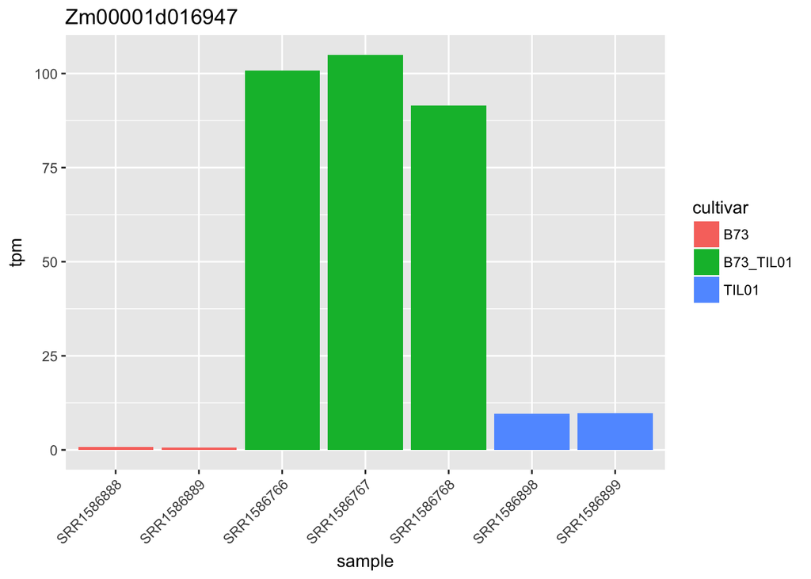

```r
gene_tpm_long %>% filter(gene == tpm_B73_top[2,]$gene) %>% ggplot() + geom_bar(aes(x=sample, y=tpm, fill=cultivar), stat = "identity") +
  theme(axis.text.x = element_text(angle = 45, hjust = 1)) + ggtitle(tpm_B73_top[2,]$gene)
```

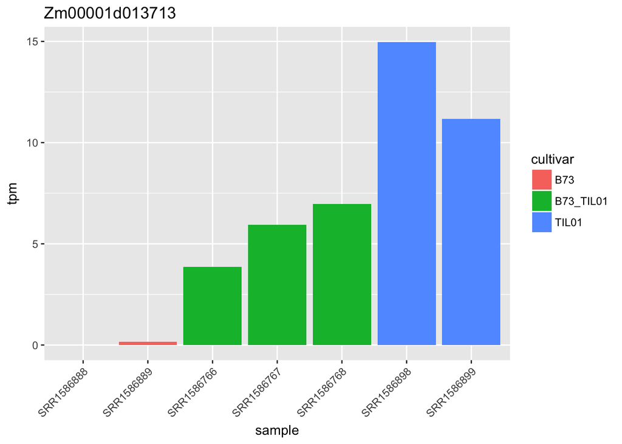

```r
gene_tpm_long %>% filter(gene == tpm_B73_top[500,]$gene) %>% ggplot() + geom_bar(aes(x=sample, y=tpm, fill=cultivar), stat = "identity") +
  theme(axis.text.x = element_text(angle = 45, hjust = 1)) + ggtitle(tpm_B73_top[500,]$gene)
```

#### Contrast for TIL01

Drop the cultivarTIL01 from the design matrix. Anything that is significant prefers the alternative full model. Meaning that the variable TIL01 explains the result better. Results from this section are differentially expressed from TIL01, but not necessarily differentially expressed from B73.

```r
tpm_fit_TIL01 <- topTable(fit, n=nrow(tpm_v), confint = TRUE, coef = "cultivarTIL01")
tpm_fit_TIL01$gene <- rownames(tpm_fit_TIL01)
tpm_TIL01_top <- tpm_fit_TIL01 %>% filter(adj.P.Val <= 0.05) %>% arrange(P.Value)
dim(tpm_TIL01_top)
```

```
## [1] 8526    9
```

```r
head(tpm_TIL01_top)
```

```
##       logFC      CI.L      CI.R   AveExpr         t      P.Value
## 1 -5.939346 -6.190056 -5.688636 3.5416830 -59.01607 4.982085e-09
## 2  4.447165  4.223880  4.670451 0.6570466  49.61639 1.311701e-08
## 3 -5.121658 -5.399113 -4.844202 1.8705543 -45.98546 2.004078e-08
## 4 -5.351301 -5.641954 -5.060648 7.0416716 -45.86565 2.033445e-08
## 5 -5.310636 -5.601349 -5.019923 3.1300256 -45.50778 2.124234e-08
## 6 -4.817758 -5.094523 -4.540992 2.8408416 -43.36471 2.779749e-08
##      adj.P.Val         B           gene
## 1 0.0001678060 10.218980 Zm00001d003567
## 2 0.0001678060  9.399191 Zm00001d022356
## 3 0.0001678060  9.208433 Zm00001d021444
## 4 0.0001678060  9.952824 Zm00001d011183
## 5 0.0001678060  9.472815 Zm00001d020883
## 6 0.0001688179  9.255902 Zm00001d051794
```

Check out pvalues

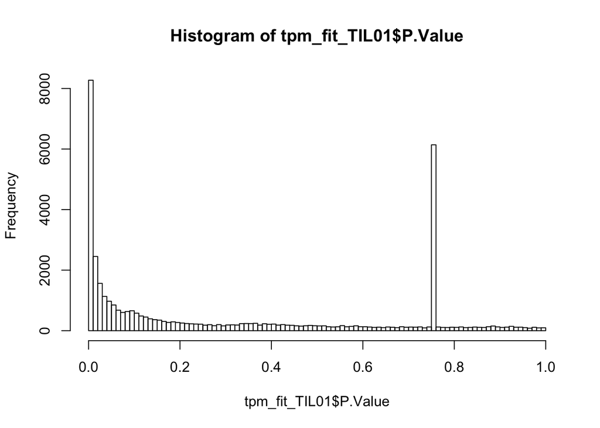

```r
hist(tpm_fit_TIL01$P.Value, breaks= 100)
```

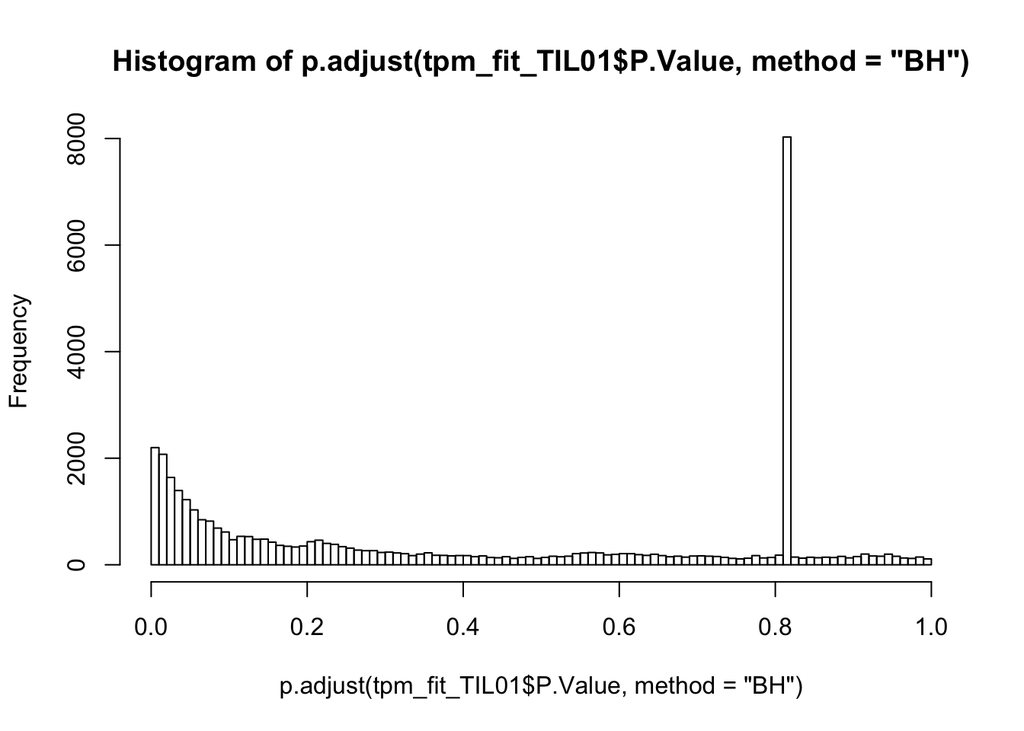

```r
hist(p.adjust(tpm_fit_TIL01$P.Value, method = "BH"), breaks=100)
```

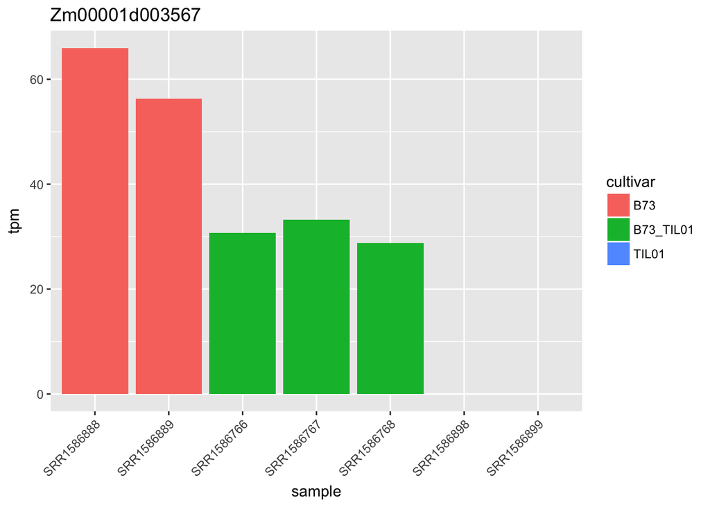

```r
gene_tpm_long %>% filter(gene == tpm_TIL01_top[1,]$gene) %>% ggplot() + geom_bar(aes(x=sample, y=tpm, fill=cultivar), stat = "identity") +
  theme(axis.text.x = element_text(angle = 45, hjust = 1)) + ggtitle(tpm_TIL01_top[1,]$gene)
```

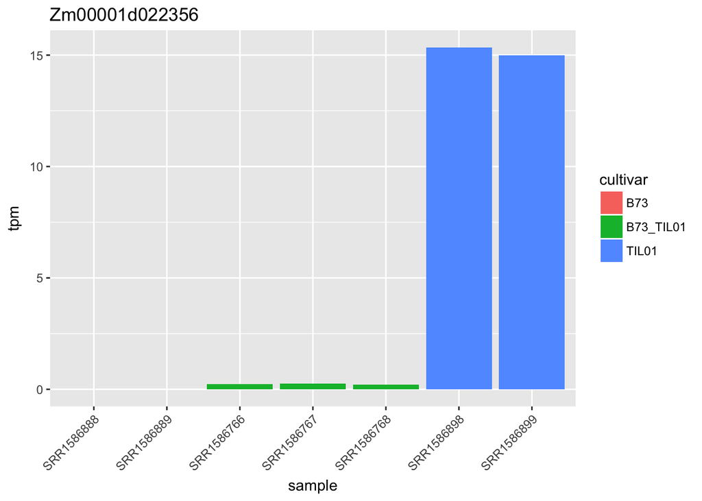

```r
gene_tpm_long %>% filter(gene == tpm_TIL01_top[2,]$gene) %>% ggplot() + geom_bar(aes(x=sample, y=tpm, fill=cultivar), stat = "identity") +
  theme(axis.text.x = element_text(angle = 45, hjust = 1)) + ggtitle(tpm_TIL01_top[2,]$gene)
```

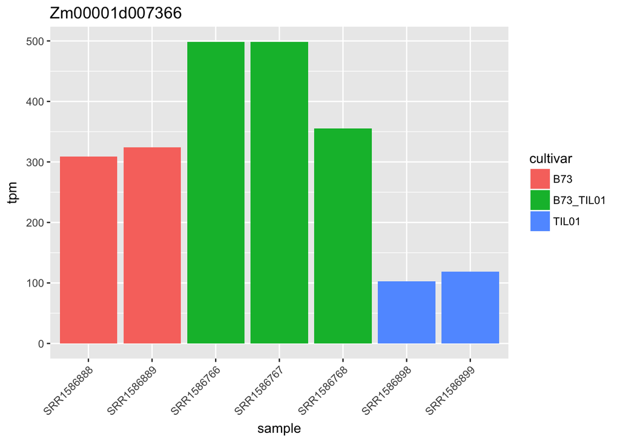

```r
gene_tpm_long %>% filter(gene == tpm_TIL01_top[500,]$gene) %>% ggplot() + geom_bar(aes(x=sample, y=tpm, fill=cultivar), stat = "identity") +
  theme(axis.text.x = element_text(angle = 45, hjust = 1)) + ggtitle(tpm_TIL01_top[500,]$gene)
```

#### merge contrast results

```r
tpm_results <- merge(tpm_B73_top, tpm_TIL01_top, by="gene")
dim(tpm_results)
```

```
## [1] 2331   17
```

Plot the logFC

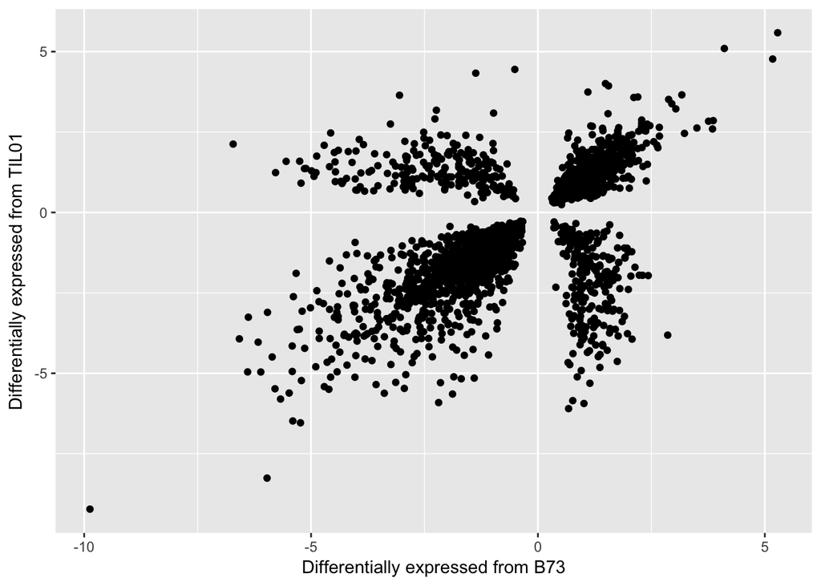

```r
tpm_results %>% ggplot() + geom_point(aes(x=logFC.x, y=logFC.y)) +
  xlab("Differentially expressed from B73") +
  ylab("Differentially expressed from TIL01")
```

The logFC is the difference between a parent and the hybrid.

| Axes | sign | meaning |
| --- | --- | --- |
| x | + | B73 > F1 |
| x | - | F1 > B73 |
| y | + | TIL01 > F1 |
| y | - | F1 > FIL01 |

```r
lfc <- tpm_results %>% select(gene, logFC.x, logFC.y, P.Value.x, P.Value.y, adj.P.Val.x, adj.P.Val.y) %>% arrange(desc(logFC.x))

head(lfc)
```

```
##             gene  logFC.x  logFC.y    P.Value.x    P.Value.y adj.P.Val.x
## 1 Zm00001d028541 5.283671 5.587470 6.498285e-06 4.229976e-06 0.001765672
## 2 Zm00001d053824 5.173410 4.770136 1.690763e-04 2.913804e-04 0.008114237
## 3 Zm00001d027988 4.108142 5.097905 8.937083e-04 2.925616e-04 0.019665567
## 4 Zm00001d051658 3.863480 2.854957 1.095905e-05 1.334426e-04 0.002142874
## 5 Zm00001d025567 3.847113 2.596138 9.114876e-06 1.085084e-04 0.001956627
## 6 Zm00001d052340 3.759942 2.836129 3.480419e-04 1.510138e-03 0.011600810
##   adj.P.Val.y
## 1 0.001211050
## 2 0.007143975
## 3 0.007163227
## 4 0.004930512
## 5 0.004557660
## 6 0.016522475
```

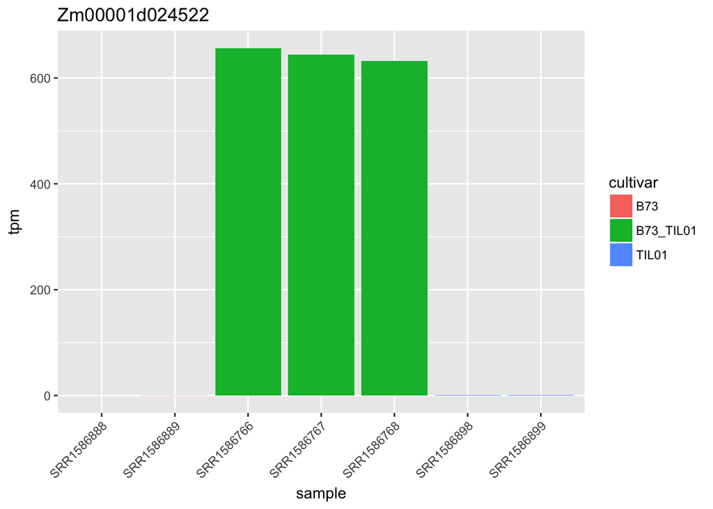

```r
gene_tpm_long %>% filter(gene == "Zm00001d024522") %>% ggplot() + geom_bar(aes(x=sample, y=tpm, fill=cultivar), stat = "identity") +
  theme(axis.text.x = element_text(angle = 45, hjust = 1)) + ggtitle("Zm00001d024522")
```

Zm00001d050635

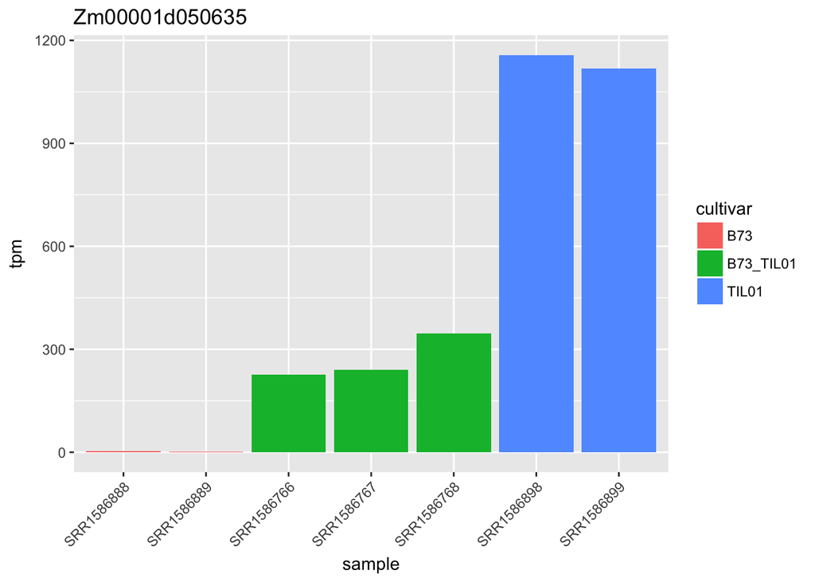

```r
gene_tpm_long %>% filter(gene == "Zm00001d050635") %>% ggplot() + geom_bar(aes(x=sample, y=tpm, fill=cultivar), stat = "identity") +
  theme(axis.text.x = element_text(angle = 45, hjust = 1)) + ggtitle("Zm00001d050635")
```

Zm00001d028541

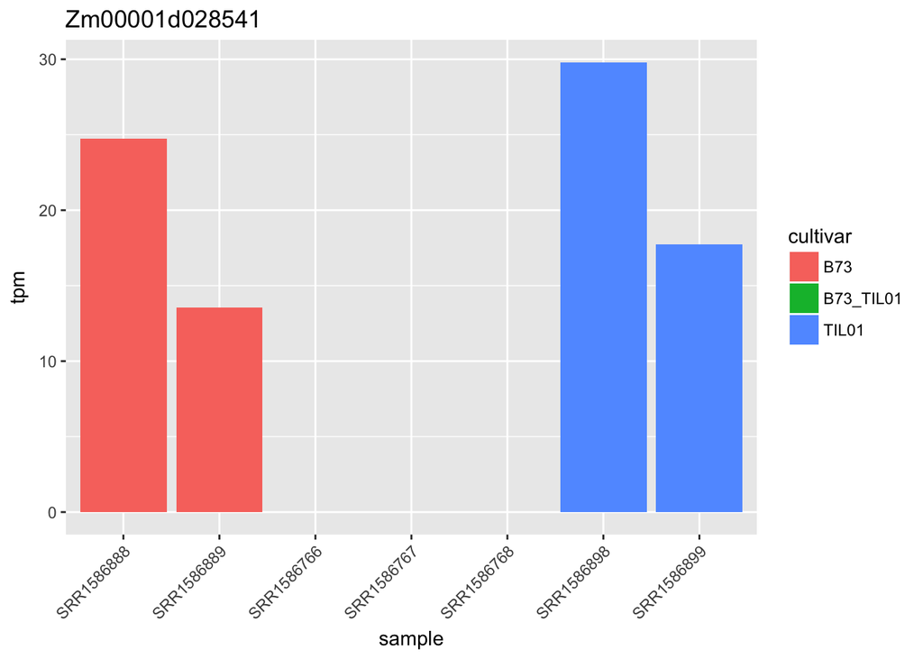

```r
gene_tpm_long %>% filter(gene == "Zm00001d028541") %>% ggplot() + geom_bar(aes(x=sample, y=tpm, fill=cultivar), stat = "identity") +
  theme(axis.text.x = element_text(angle = 45, hjust = 1)) + ggtitle("Zm00001d028541")
```

Zm00001d052340

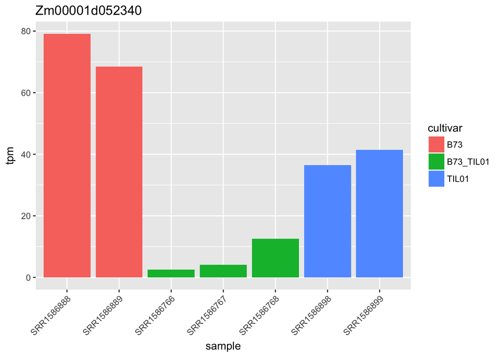

```r
gene_tpm_long %>% filter(gene == "Zm00001d052340") %>% ggplot() + geom_bar(aes(x=sample, y=tpm, fill=cultivar), stat = "identity") +
  theme(axis.text.x = element_text(angle = 45, hjust = 1)) + ggtitle("Zm00001d052340")
```

## Design matrix for F1

```r
meta_leaf$F1 <- meta_leaf$cultivar == "B73_TIL01"
meta_leaf$cultivar <- factor(meta_leaf$cultivar, levels=c("B73", "TIL01", "B73_TIL01"))
f1_model <- model.matrix(~1+F1, meta_leaf)
```

voom

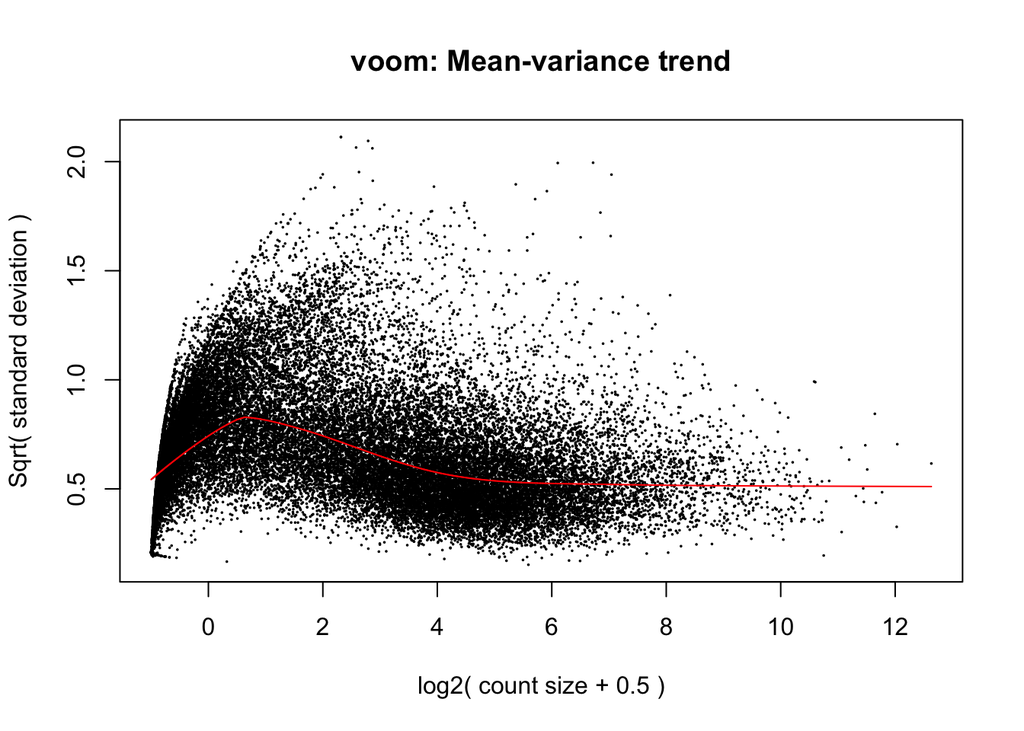

```r
tpm_f1_v <- voom(tpm_dge, design = f1_model, plot=TRUE)
```

```r
fit_f1 <- lmFit(tpm_f1_v, design = full_leaf_model)
fit_f1 <- eBayes(fit_f1)
tpm_fit_f1 <- topTable(fit_f1, n=nrow(tpm_f1_v), confint = TRUE)
```

```
## Removing intercept from test coefficients
```

```r
tpm_fit_f1$gene <- rownames(tpm_fit_f1)
tpm_f1_top <- tpm_fit_f1 %>% filter(adj.P.Val <= 0.05) %>% arrange(P.Value)
dim(tpm_f1_top)
```

```
## [1] 8956    7
```

```r
head(tpm_f1_top)
```

```
##   cultivarB73 cultivarTIL01  AveExpr        F      P.Value    adj.P.Val
## 1   0.6739243     -6.096189 4.552323 1819.925 7.230320e-09 0.0001287162
## 2   1.0158601     -5.939757 3.541683 1623.429 1.007742e-08 0.0001287162
## 3  -5.5528116      1.589134 4.241686 1305.523 1.898045e-08 0.0001287162
## 4   1.1425722     -5.311040 3.130026 1211.333 2.359126e-08 0.0001287162
## 5  -9.8662794     -9.222542 3.850114 1193.129 2.465170e-08 0.0001287162
## 6  -3.5679090     -5.350964 7.041672 1184.863 2.515445e-08 0.0001287162
##             gene
## 1 Zm00001d003796
## 2 Zm00001d003567
## 3 Zm00001d024014
## 4 Zm00001d020883
## 5 Zm00001d024522
## 6 Zm00001d011183
```

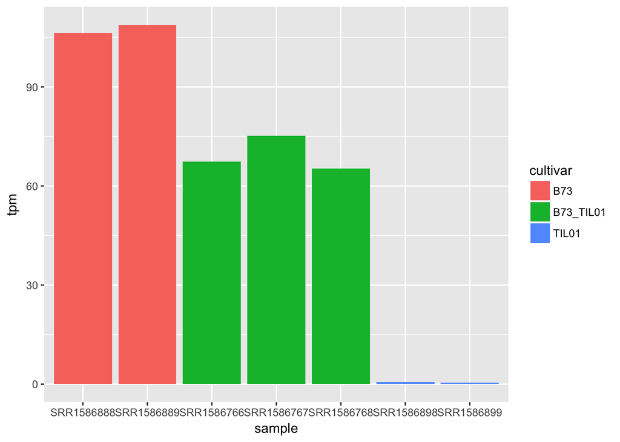

```r
gene_tpm_long %>% filter(gene == "Zm00001d003796") %>% ggplot() + geom_bar(aes(x=sample, y=tpm, fill=cultivar), stat = "identity")
```

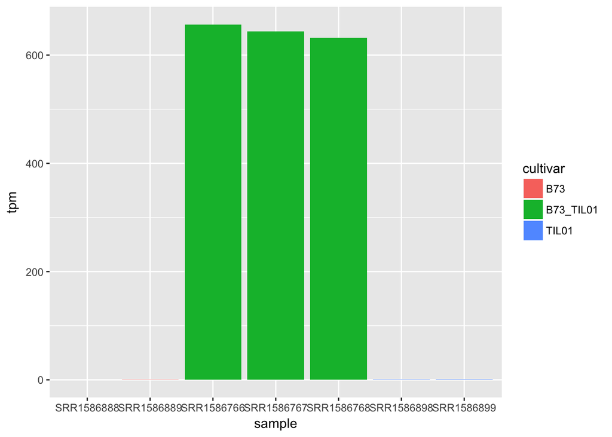

```r
gene_tpm_long %>% filter(gene == "Zm00001d024522") %>% ggplot() + geom_bar(aes(x=sample, y=tpm, fill=cultivar), stat = "identity")
```

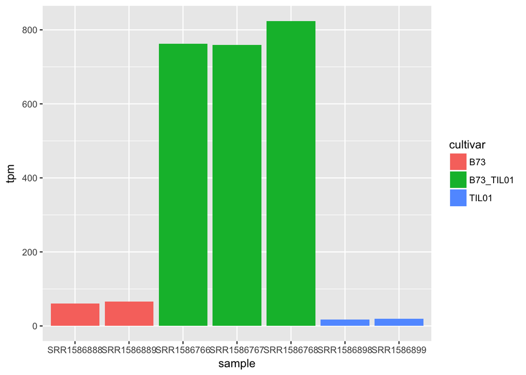

```r
gene_tpm_long %>% filter(gene == "Zm00001d011183") %>% ggplot() + geom_bar(aes(x=sample, y=tpm, fill=cultivar), stat = "identity")
```

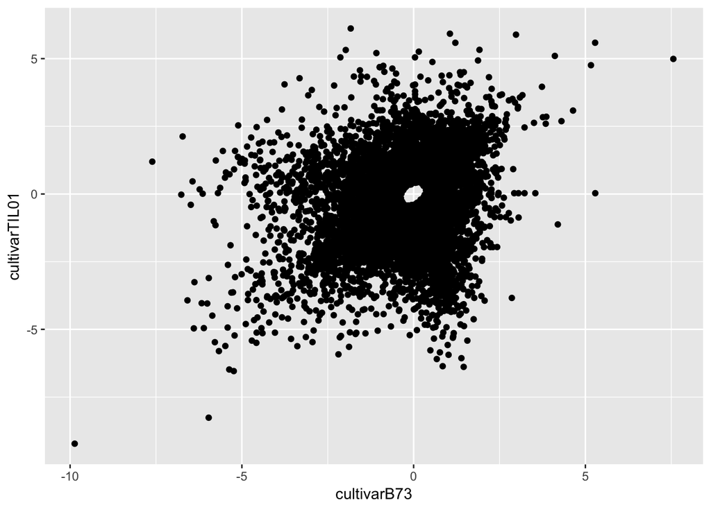

```r
tpm_f1_top %>% ggplot() + geom_point(aes(x=cultivarB73, y=cultivarTIL01))
```

Not in previous results

```r
dunno <- tpm_f1_top[!(tpm_f1_top$gene %in% tpm_results$gene),]
dim(dunno)
```

```
## [1] 6626    7
```

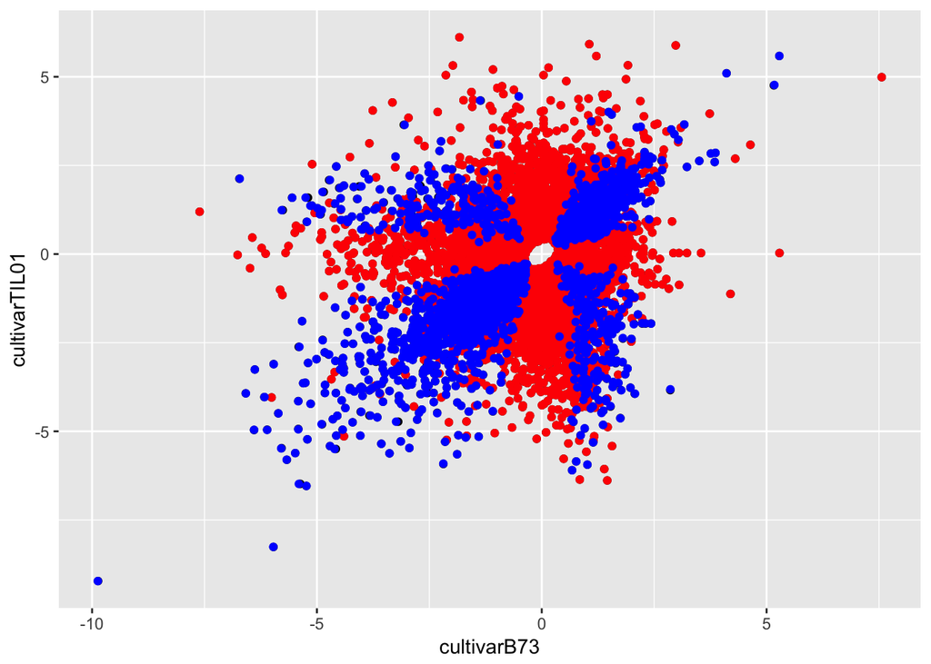

```r
tpm_f1_top %>% ggplot() +
  geom_point(aes(x=cultivarB73, y=cultivarTIL01)) +
  geom_point(data = dunno, aes(x=cultivarB73, y=cultivarTIL01), colour="red") +
  geom_point(data = tpm_results, aes(x=logFC.x, y=logFC.y), colour="blue")
```

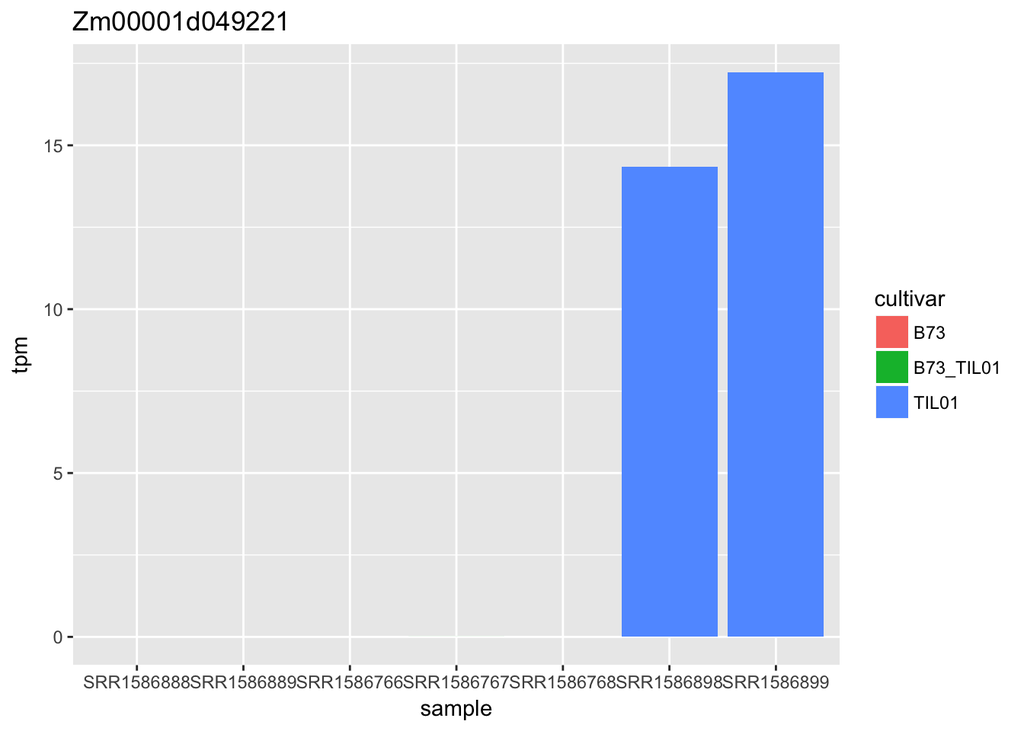

```r
gene_tpm_long %>%
  filter(gene == dunno[1,]$gene)%>%
  ggplot() + geom_bar(aes(x=sample, y=tpm, fill=cultivar), stat = "identity") + ggtitle(dunno[1,]$gene)
```

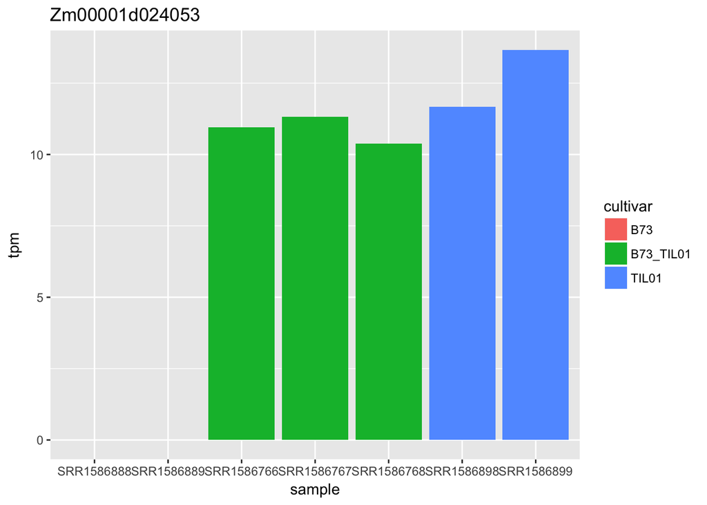

```r
gene_tpm_long %>%
  filter(gene == dunno[2,]$gene)%>%
  ggplot() + geom_bar(aes(x=sample, y=tpm, fill=cultivar), stat = "identity") + ggtitle(dunno[2,]$gene)
```

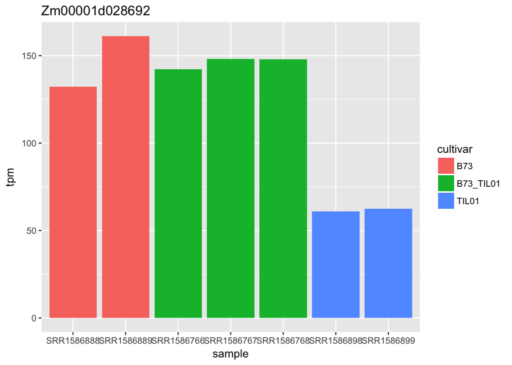

```r
gene_tpm_long %>%
  filter(gene == dunno[500,]$gene)%>%
  ggplot() + geom_bar(aes(x=sample, y=tpm, fill=cultivar), stat = "identity") + ggtitle(dunno[500,]$gene)
```